# STAT 341/641 Lab: Week Two

**Solution:**

```r
# Question 1)

# Summary functions calculate their values within each group when used with mutate() or filter() and group_by(), same as offset functions. Arithmetic operators are not affected by grouping

# Question 2) N988AT

  flights %>%
  filter(!is.na(tailnum)) %>%
  mutate(on_time = !is.na(arr_time) & (arr_delay <= 0)) %>%
  group_by(tailnum) %>%
  summarise(on_time = mean(on_time), n = n()) %>% filter(n>=30) %>%
  filter(min_rank(on_time) == 1)
```

```
## # A tibble: 1 x 3
##   tailnum on_time     n
##   <chr>     <dbl> <int>
## 1 N988AT    0.189    37
```

```r
# Question 3) Morning flights have fewer delays

  flights %>%
  group_by(hour) %>%
  summarise(arr_delay = mean(arr_delay, na.rm = TRUE)) %>%
  arrange(arr_delay)
```

```
## # A tibble: 20 x 2
##     hour arr_delay
##    <dbl>     <dbl>
##  1     7    -5.30
##  2     5    -4.80
##  3     6    -3.38
##  4     9    -1.45
##  5     8    -1.11
##  6    10     0.954
##  7    11     1.48
##  8    12     3.49
##  9    13     6.54
## 10    14     9.20
## 11    23    11.8
## 12    15    12.3
## 13    16    12.6
## 14    18    14.8
## 15    22    16.0
## 16    17    16.0
## 17    19    16.7
## 18    20    16.7
## 19    21    18.4
## 20     1   NaN
```

```r
# Question 4)

  flights %>%
  filter(arr_delay > 0) %>%
  group_by(dest) %>%
  mutate(
    arr_delay_total = sum(arr_delay),
    arr_delay_prop = arr_delay / arr_delay_total
  ) %>%
  select(
    dest, month, day, dep_time, carrier, flight,
    arr_delay, arr_delay_prop
  ) %>%
  arrange(dest, desc(arr_delay_prop))
```

```
## # A tibble: 133,004 x 8
## # Groups:   dest [103]
##    dest  month   day dep_time carrier flight arr_delay arr_delay_prop
##    <chr> <int> <int>    <int> <chr>    <int>     <dbl>          <dbl>
##  1 ABQ       7    22     2145 B6        1505       153         0.0341
##  2 ABQ      12    14     2223 B6          65       149         0.0332
##  3 ABQ      10    15     2146 B6          65       138         0.0308
##  4 ABQ       7    23     2206 B6        1505       137         0.0305
##  5 ABQ      12    17     2220 B6          65       136         0.0303
##  6 ABQ       7    10     2025 B6        1505       126         0.0281
##  7 ABQ       7    30     2212 B6        1505       118         0.0263
##  8 ABQ       7    28     2038 B6        1505       117         0.0261
##  9 ABQ      12     8     2049 B6          65       114         0.0254
## 10 ABQ       9     2     2212 B6        1505       109         0.0243
## # … with 132,994 more rows
```

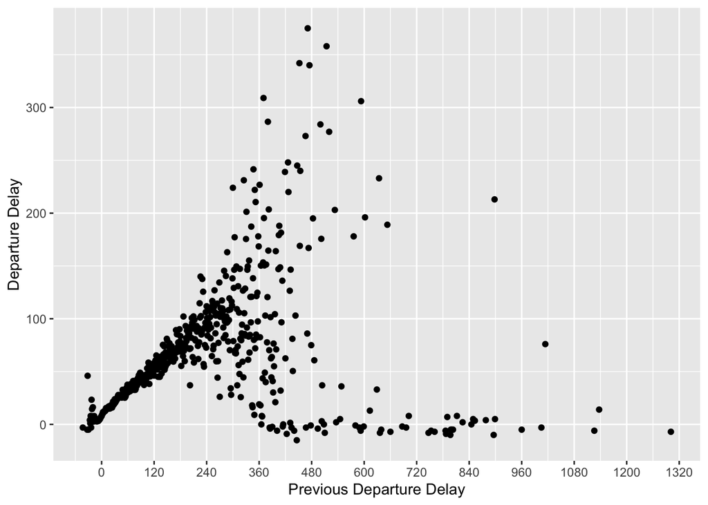

```r
# Question 5) Similar Relatinoship

  lagged <- flights %>%
  arrange(origin, month, day, dep_time) %>%
  group_by(origin) %>%
  mutate(dep_delay_lag = lag(dep_delay)) %>%
  filter(!is.na(dep_delay), !is.na(dep_delay_lag))
  lagged %>%
  group_by(dep_delay_lag) %>%
  summarise(dep_delay_mean = mean(dep_delay)) %>%
  ggplot(aes(y = dep_delay_mean, x = dep_delay_lag)) +
  geom_point() +
  scale_x_continuous(breaks = seq(0, 1500, by = 120)) +
  labs(y = "Departure Delay", x = "Previous Departure Delay")
```

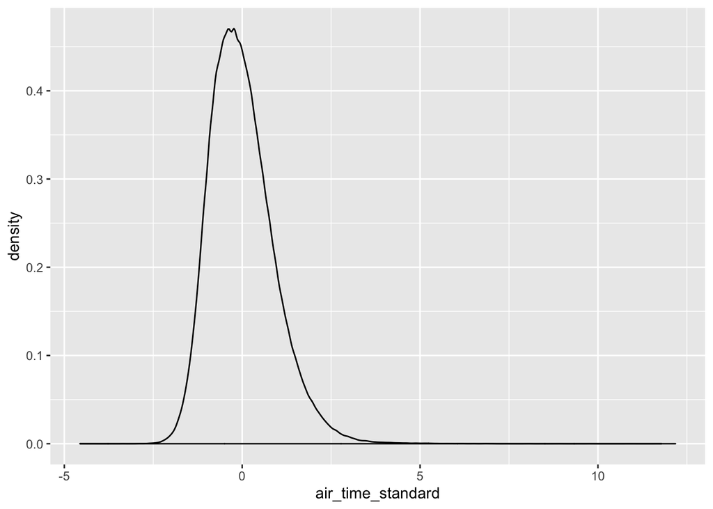

```r
# Question 6) Standaridze flights to plot a distribution, fast flights are those flights with the smallest standardized values, the most delayed flight was DL841 from JFK to SFO

  standardized_flights <- flights %>%
  filter(!is.na(air_time)) %>%
  group_by(dest, origin) %>%
  mutate(
    air_time_mean = mean(air_time),
    air_time_sd = sd(air_time),
    n = n()
  ) %>%
  ungroup() %>%
  mutate(air_time_standard = (air_time - air_time_mean) / (air_time_sd + 1))
  ggplot(standardized_flights, aes(x = air_time_standard)) +
  geom_density()
```

```r
air_time_delayed <-
  flights %>%
  group_by(origin, dest) %>%
  mutate(
    air_time_min = min(air_time, na.rm = TRUE),
    air_time_delay = air_time - air_time_min,
    air_time_delay_pct = air_time_delay / air_time_min * 100
  )
air_time_delayed %>%
  arrange(desc(air_time_delay)) %>%
  select(
    air_time_delay, carrier, flight,
    origin, dest, year, month, day, dep_time,
    air_time, air_time_min
  ) %>%
  head() %>%
  print(width = Inf)
```

```
## # A tibble: 6 x 11
## # Groups:   origin, dest [5]
##   air_time_delay carrier flight origin dest   year month   day dep_time air_time
##            <dbl> <chr>    <int> <chr>  <chr> <int> <int> <int>    <int>    <dbl>
## 1            189 DL         841 JFK    SFO    2013     7    28     1727      490
## 2            165 DL         426 JFK    LAX    2013    11    22     1812      440
## 3            163 AA         575 JFK    EGE    2013     1    28     1806      382
## 4            147 DL          17 JFK    LAX    2013     7    10     1814      422
## 5            145 UA         745 LGA    DEN    2013     9    10     1513      331
## 6            143 UA         587 EWR    LAS    2013    11    22     2142      399
##   air_time_min
##          <dbl>
## 1          301
## 2          275
## 3          219
## 4          275
## 5          186
## 6          256
```

```r
# Question 7) The carrier expressJet Airlines Inc flies to the most destinations

  flights %>%
  # find all airports with > 1 carrier
  group_by(dest) %>%
  mutate(n_carriers = n_distinct(carrier)) %>%
  filter(n_carriers > 1) %>%
  # rank carriers by number of destinations
  group_by(carrier) %>%
  summarize(n_dest = n_distinct(dest)) %>%
  arrange(desc(n_dest))
```

```
## # A tibble: 16 x 2
##    carrier n_dest
##    <chr>    <int>
##  1 EV          51
##  2 9E          48
##  3 UA          42
##  4 DL          39
##  5 B6          35
##  6 AA          19
##  7 MQ          19
##  8 WN          10
##  9 OO           5
## 10 US           5
## 11 VX           4
## 12 YV           3
## 13 FL           2
## 14 AS           1
## 15 F9           1
## 16 HA           1
```

```r
# Question 8)
flights %>%
  # sort in increasing order
  select(tailnum, year, month, day, dep_delay) %>%
  filter(!is.na(dep_delay)) %>%
  arrange(tailnum, year, month, day) %>%
  group_by(tailnum) %>%
  # cumulative number of flights delayed over one hour
  mutate(cumulative_hr_delays = cumsum(dep_delay > 60)) %>%
  # count the number of flights == 0
  summarise(total_flights = sum(cumulative_hr_delays < 1)) %>%
  arrange(total_flights)
```

```
## # A tibble: 4,037 x 2
##    tailnum total_flights
##    <chr>           <int>
##  1 D942DN              0
##  2 N10575              0
##  3 N11106              0
##  4 N11109              0
##  5 N11187              0
##  6 N11199              0
##  7 N12967              0
##  8 N13550              0
##  9 N136DL              0
## 10 N13903              0
## # … with 4,027 more rows
```

#**Task Two: Outlier Detection**

Analyze the flight data from the previous question. Fit a linear model for departures delay. Then compute the mean-squared error and R-squared. Next, use any of the outlier detection techniques to look for outlying values in the data. After you have done this, fit separate models for the non-outlier and the outliers. Report the mean-squared error and the R-squared.

(Hint: check out ?flights. Try to join the flight data to the weather data to build a better model.)

You may find the text *ggplot2 Elegant Graphics for Data Analysis* to be helpful.

```r
install.packages("solitude")
# Merging and cleaning data
flights.data <- subset(flights,select = c(arr_delay,dep_delay))
flights.data <- subset(flights.data,!(arr_delay == ""))
flights.data <- subset(flights.data,!(dep_delay == ""))
flights.data
```

```
## # A tibble: 327,346 x 2
##    arr_delay dep_delay
##        <dbl>     <dbl>
##  1        11         2
##  2        20         4
##  3        33         2
##  4       -18        -1
##  5       -25        -6
##  6        12        -4
##  7        19        -5
##  8       -14        -3
##  9        -8        -3
## 10         8        -2
## # … with 327,336 more rows
```

```r
flights.lm <- lm(dep_delay ~ arr_delay,data = flights.data)
print (flights.lm)
```

```
##
## Call:
## lm(formula = dep_delay ~ arr_delay, data = flights.data)
##
## Coefficients:
## (Intercept)    arr_delay
##      6.8928       0.8212
```

```r
summ <- summary(flights.lm)
summ
```

```
##
## Call:
## lm(formula = dep_delay ~ arr_delay, data = flights.data)
##
## Residuals:
##      Min       1Q   Median       3Q      Max
## -168.203   -8.429    0.352    8.849  249.560
##
## Coefficients:
##              Estimate Std. Error t value Pr(>|t|)
## (Intercept) 6.8927739  0.0286198   240.8   <2e-16 ***
## arr_delay   0.8211853  0.0006337  1295.8   <2e-16 ***
## ---
## Signif. codes:  0 '***' 0.001 '**' 0.01 '*' 0.05 '.' 0.1 ' ' 1
##
## Residual standard error: 16.18 on 327344 degrees of freedom
## Multiple R-squared:  0.8369, Adjusted R-squared:  0.8369
## F-statistic: 1.679e+06 on 1 and 327344 DF,  p-value: < 2.2e-16
```

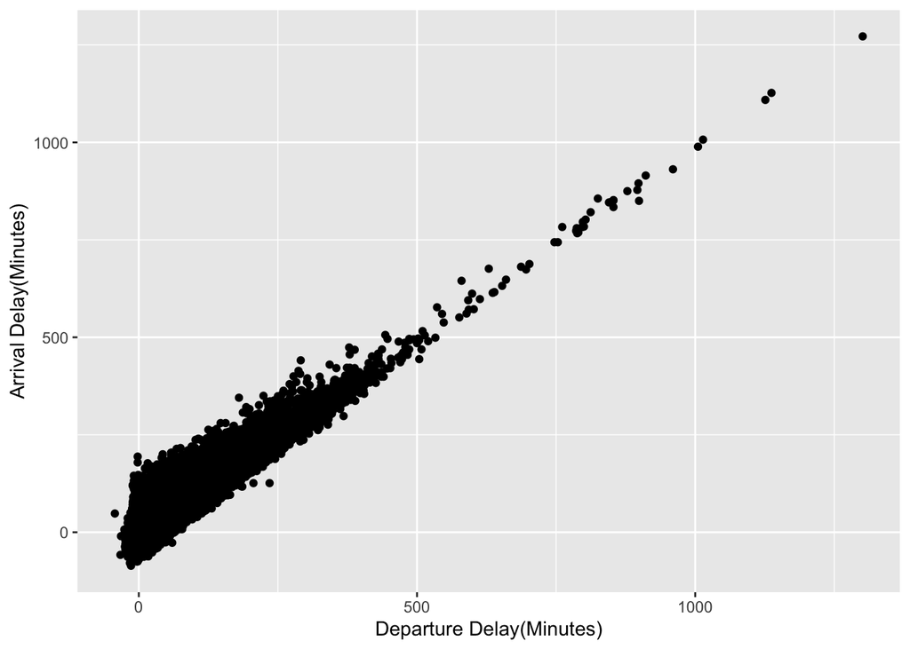

```r
ggplot(flights.lm)+ geom_point(mapping= aes(x =dep_delay, y = arr_delay))+ labs(x = "Departure Delay(Minutes)", y="Arrival Delay(Minutes)")
```

```r
mean((flights.lm$residuals)^2)
```

```
## [1] 261.8746
```

```r
# Plot of dep_delay against arrival delay to see how much delayed flights affect arrival delay
# R squared = 0.8369 or 83.69% . The Values are close to the regression line
# The mean squared error is 261.8746 which is a very large error value, which means that the data is dispersed widely around the central mean.

# I will try and use isolation forest outlier detection technique
library(solitude)
isf <- isolationForest$new()
isf$fit(flights.data)
```

```
## Building Isolation Forest ... done
## Computing depth of terminal nodes ... done
```

```r
# Predict outliers
flights.data$predict <- isf$predict(flights.data)
flights.data$outlier <- as.factor(ifelse(flights.data$predict$anomaly_score >= 0.33801,"outlier","normal"))
# Plotting outliers and non outliers
data.outlier <- subset(flights.data,outlier == "outlier")
data.normal <- subset(flights.data,outlier == "normal")
outlier.lm <- lm(dep_delay ~ arr_delay,data = data.outlier)
summary(outlier.lm)
```

```
##
## Call:
## lm(formula = dep_delay ~ arr_delay, data = data.outlier)
##
## Residuals:
##     Min      1Q  Median      3Q     Max
## -71.728  -6.639   4.628  14.130  40.866
##
## Coefficients:
##             Estimate Std. Error t value Pr(>|t|)
## (Intercept)  2.30493   13.98446   0.165     0.87
## arr_delay    1.00686    0.01803  55.856   <2e-16 ***
## ---
## Signif. codes:  0 '***' 0.001 '**' 0.01 '*' 0.05 '.' 0.1 ' ' 1
##
## Residual standard error: 21.31 on 48 degrees of freedom
## Multiple R-squared:  0.9848, Adjusted R-squared:  0.9845
## F-statistic:  3120 on 1 and 48 DF,  p-value: < 2.2e-16
```

```r
mean(outlier.lm$residuals^2)
```

```
## [1] 436.135
```

```r
normal.lm <- lm(dep_delay ~ arr_delay,data = data.normal)
summary(normal.lm)
```

```
##
## Call:
## lm(formula = dep_delay ~ arr_delay, data = data.normal)
##
## Residuals:
##      Min       1Q   Median       3Q      Max
## -166.568   -8.430    0.258    8.759  136.291
##
## Coefficients:
##              Estimate Std. Error t value Pr(>|t|)
## (Intercept) 6.9304503  0.0284539   243.6   <2e-16 ***
## arr_delay   0.8125632  0.0006447  1260.4   <2e-16 ***
## ---
## Signif. codes:  0 '***' 0.001 '**' 0.01 '*' 0.05 '.' 0.1 ' ' 1
##
## Residual standard error: 16.09 on 327294 degrees of freedom
## Multiple R-squared:  0.8292, Adjusted R-squared:  0.8292
## F-statistic: 1.589e+06 on 1 and 327294 DF,  p-value: < 2.2e-16
```

```r
mean(normal.lm$residuals^2)
```

```
## [1] 258.7304
```

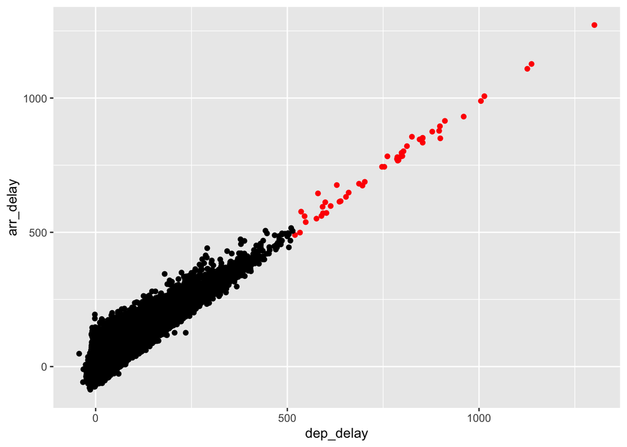

```r
ggplot() + geom_point(data = data.outlier,aes(x = dep_delay, y=arr_delay), color = 'red') + geom_point(data = data.normal,aes(x = dep_delay, y=arr_delay), color = 'black')
```

```r
# The value of R Squared for the outlier model is 0.9845 ~ 98.45%
# The value of the mean squared error for the outlier model = 436.135
# The value of R Squared of the normal data = 0.8292  ~ 82.92%
# The value of the mean squared error of the normal model = 258.7304

# They are both close to their respective regression line which means they are good estimates of outliers and noral values.
```